# Lab 5: Insurance Costs

Author

Lily

**GitHub Repository**: https://github.com/lilysteinberg/GSB-544---Computing-and-ML/tree/main/Week%205

# 1. Data Exploration

**1. Read in the dataset and display some summaries of the data.**

This hidden code loads in the necessary packages.

```python
# packages
import pandas as pd
import numpy as np
from plotnine import *
from sklearn.linear_model import LinearRegression
from sklearn.metrics import mean_squared_error, r2_score
```

This hidden code imports the data.

```python
# data
insurance = pd.read_csv("https://www.dropbox.com/s/bocjjyo1ehr5auz/insurance_costs_1.csv?dl=1")
```

This code previews the data and shows a statsticial summary.

```python
# preview columns and data
#print(insurance.head())

# statstical summary
insurance.describe()
```

|  | age | bmi | charges |
| --- | --- | --- | --- |
| count | 431.000000 | 431.000000 | 431.000000 |
| mean | 37.960557 | 30.768898 | 12297.098118 |
| std | 16.363909 | 6.111362 | 11876.527128 |
| min | 18.000000 | 15.960000 | 1131.506600 |
| 25% | 22.000000 | 26.357500 | 2710.444575 |
| 50% | 34.000000 | 30.590000 | 9866.304850 |
| 75% | 55.000000 | 35.272500 | 14510.872600 |
| max | 64.000000 | 49.060000 | 55135.402090 |

**2. Fix any concerns you have about the data.**

```python
# look for missing data and decide how to handle it
insurance.isna().any() # all false, so no missing data

# checking data types
print(insurance.dtypes) # all numeric columns are apporpriatly numeric already

# check for outliers
## future plotting shows there are none that I want to omit
```

```
age          int64
sex         object
bmi        float64
smoker      object
region      object
charges    float64
dtype: object
```

**3. Make up to three plots comparing the response variable (`charges`) to one of the predictor variables. Briefly describe each plot.**

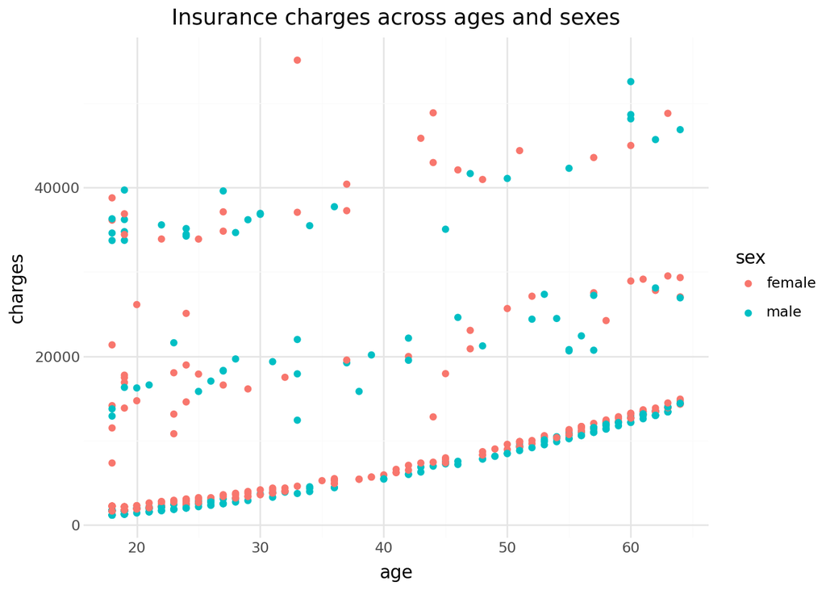

```python
(ggplot(insurance,
        aes(x = "age",
            y = "charges",
            color = "sex"))
+ geom_point()
+ labs(title = "Insurance charges across ages and sexes")
+ theme_minimal()
)
```

This plot shows that insurance charges generally increase as age increases. There is a steady trendline for this at the bottom, with two tiers of less dense bands that follow this trend at higher average charges, as well.

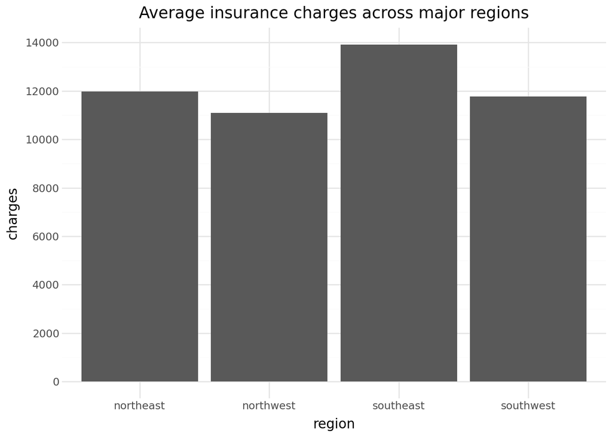

```python
# finding mean charges by region
df_plot = insurance[["charges", "region"]].groupby("region").mean().reset_index()

(ggplot(df_plot,
        aes(x = "region",
            y = "charges"))
+ geom_col()
+ scale_y_continuous(breaks = range(0,15000,2000))
+ labs(title= "Average insurance charges across major regions")
+ theme_minimal()
)
```

This plot shows that the southeast region has the largest average insurance charges, with northwest having the least. The overall range is approximately 11,000 to 14,000.

# 2. Simple Linear Models

**1. Construct a simple linear model to predict the insurance charges from the beneficiary’s age. Discuss the model fit, and interpret the coefficient estimates.**

```
Intercept =  3611.758798507106
Coefficient =  [228.79904937]
```

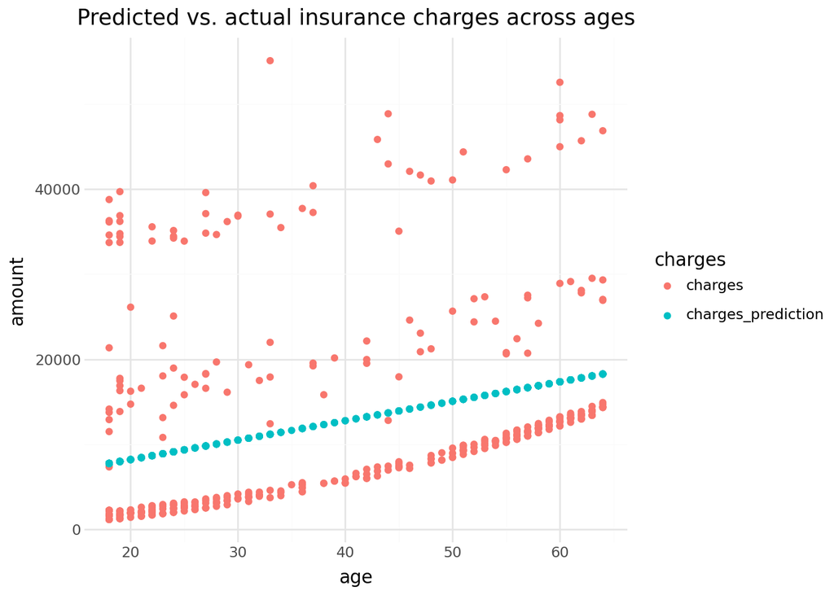

```python
### fit the model
model_1 = LinearRegression()
model_1.fit(
    X = insurance[["age"]],
    y = insurance["charges"]
)

print("Intercept = ", model_1.intercept_)
print("Coefficient = ", model_1.coef_)

### plot
# add prediction column
insurance["charges_prediction"] = model_1.predict(insurance[["age"]])
# wide to long
long_plot = insurance.melt(insurance[["age"]], value_vars = ["charges", "charges_prediction"], var_name = "charges", value_name = "amount")

(ggplot(long_plot,
        aes(x = "age",
            y = "amount",
            color = "charges"))
+ geom_point()
+ labs(title = "Predicted vs. actual insurance charges across ages")
+ theme_minimal()
)
```

As seen in the graph, Model 1 generally follows the baseline positive trend seen with a majority of the data. The predictions are higher than the lowest, most common trendline, and lower than the second tier of insurance charges, and much below the third tier. The predictions do not overlap with nearly any actual datapoints. This does not feel like a good model fit.

The model intercept occurs at 3611.76. This means that at age 0, a patient is predicted to have $3,611.76 insurance charges, on average. While this may not always make the most economic sense, it grounds the model at an appropriate starting place.

**2. Make a model that also incorporates the variable sex. Report your results.**

```
Intercept =  3315.332346534262
Coefficients =  [228.42586236 649.83258997]
```

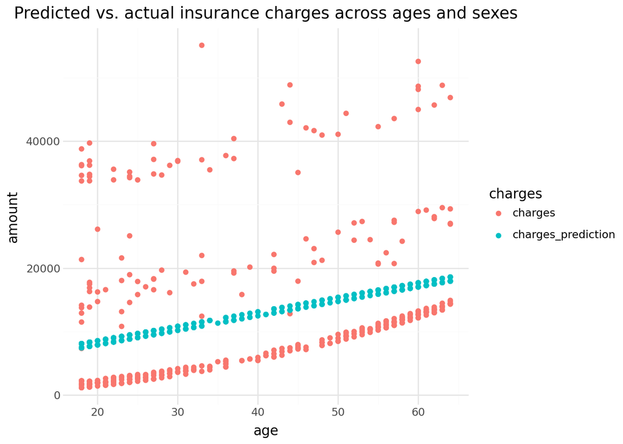

```python
### make dummies and convert the resulting bools to numbers
insurance = pd.get_dummies(insurance, drop_first = True)
insurance = insurance * 1
# omitted dummy variables that are now the benchmark: sex_female, smoker_no, region_northeast

### fit the model
model_2 = LinearRegression()
model_2.fit(
    X = insurance[["age", "sex_male"]],
    y = insurance["charges"]
)

print("Intercept = ", model_2.intercept_)
print("Coefficients = ", model_2.coef_)

### plot
# add prediction column
insurance["charges_prediction"] = model_2.predict(insurance[["age", "sex_male"]])
# wide to long
long_plot = insurance.melt(insurance[["age", "sex_male"]], value_vars = ["charges", "charges_prediction"], var_name = "charges", value_name = "amount")

(ggplot(long_plot,
        aes(x = "age",
            y = "amount",
            color = "charges"))
+ geom_point()
+ labs(title = "Predicted vs. actual insurance charges across ages and sexes")
+ theme_minimal()
)
```

Again, as seen in the graph, Model 2 generally follows the baseline positive trend seen with a majority of the data, and the predictions do not overlap with nearly any actual datapoints. This time, the prediction includes a slight adjustment for whether the patient is categorized as female or male, seen with the doubled-up trendline. This still does not feel like a good model fit.

Model 2’s coefficient associated with the age predictor variable is around 228.43, which means that as a patient grows a year older, the predicted insurance charges increase by $228.43, holding sex constant.

Model 2’s coefficient associated with the sex predictor variable is around 649.83, meaning that men pay $649.83 more on average than women, holding age constant. Although women seem to pay more at the more defined, lower trendline, as seen in one of the initial plots produced in Part One, men do have higher insurance charges, on average, when accounting for the other datapoints.

**3. Now make a model that does not include sex, but does include smoker. Report your results.**

```
Intercept =  -2166.852295375429
Coefficients =  [  253.14535549 24048.86743795]
```

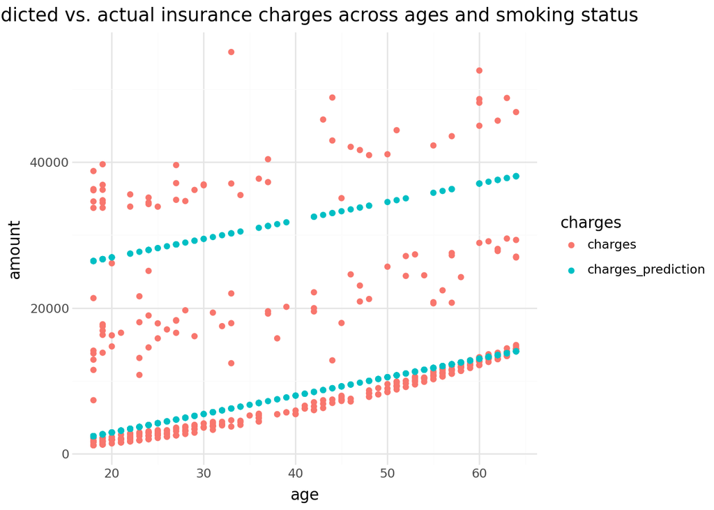

```python
### fit the model
model_3 = LinearRegression()
model_3.fit(
    X = insurance[["age", "smoker_yes"]],
    y = insurance["charges"]
)

print("Intercept = ", model_3.intercept_)
print("Coefficients = ", model_3.coef_)

### plot
# add prediction column
insurance["charges_prediction"] = model_3.predict(insurance[["age", "smoker_yes"]])
# wide to long
long_plot = insurance.melt(insurance[["age", "smoker_yes"]], value_vars = ["charges", "charges_prediction"], var_name = "charges", value_name = "amount")

(ggplot(long_plot,
        aes(x = "age",
            y = "amount",
            color = "charges"))
+ geom_point()
+ labs(title = "Predicted vs. actual insurance charges across ages and smoking status")
+ theme_minimal()
)
```

Model 3 generally follows the baseline positive trend seen with a majority of the data, and the predictions overlap with a few more actual datapoints than the other two models so far. This time, the prediction includes a more pronounced adjustment for whether the patient smokes or not, seen with the two trendlines.

Model 3’s coefficient associated with the age predictor variable is around 253.14, which means that as a patient grows a year older, the predicted insurance charges increase by $253.14, holding smoker status constant.

Model 3’s coefficient associated with the smoker status predictor variable is around 24048.87, meaning that smokers pay $24,048.87 more on average than non-smokers, holding age constant.

**4. Which model (Q2 or Q3) do you think better fits the data? Justify your answer by calculating the MSE for each model, and also by comparing R-squared values.**

This hidden code defines a custom function for calculating MSE and R-squared values.

```python
def goodness_fit (df, y_var, models):
  """
  Returns a table of MSE and R2 values based on given data and models

  Parameters
  ----------
  df: dataframe
    dataframe
  y_var: series
    column of dataframe that includes the y variable used in the model
  models: dict
    dictionary of models that lists each model's x variable(s)

  Return
  ------
  dataframe
    MSE and R-squared values for each provided model
  """
  rows = []
  for name, Xcols in models.items():
    # go thru list of models pulling data from X variables
    X_var = df[Xcols]
    # fit model based on columns in model list above
    model = LinearRegression().fit(X_var, y_var)
    # make predictions
    y_var_ = model.predict(df[Xcols])
    # save it
    df[f"{name}_predict"] = y_var_
    # calculate MSE
    mse = mean_squared_error(y_var, y_var_)
    # calculate r-squared
    r2 = r2_score(y_var, y_var_)
    # save data to df
    rows.append({"Model": name, "MSE": mse, "R2": r2})

  df_error = pd.DataFrame(rows)
  return df_error
```

```python
# list models to compare based on x variables
models = {
    "Model 1": ["age"],
    "Model 2": ["age", "sex_male"],
    "Model 3": ["age", "smoker_yes"]
}

goodness_fit(insurance, insurance["charges"], models)
```

|  | Model | MSE | R2 |
| --- | --- | --- | --- |
| 0 | Model 1 | 1.267393e+08 | 0.099381 |
| 1 | Model 2 | 1.266339e+08 | 0.100130 |
| 2 | Model 3 | 3.371983e+07 | 0.760384 |

Model 3 fits the data better. The graph visually shows predictions that better match the data. Additionally, Model 3 has a smaller MSE and larger R-squared value than Model 2.

# 3. Multiple Linear Models

**1. Fit a model that uses age and bmi as predictors. (Do not include an interaction term, age*bmi, between these two.) Report your results. How does the MSE compare to the model in Part Two Q1? How does the R-squared compare?**

```python
### fit the model
model_4 = LinearRegression()
model_4.fit(
    X = insurance[["age", "bmi"]],
    y = insurance["charges"]
)

print("Intercept = ", model_4.intercept_)
print("Coefficients = ", model_4.coef_)

### compare the models
# list models to compare based on x variables
models = {
    "Model 1": ["age"],
    "Model 4": ["age", "bmi"]
}

# call custom function for calculating goodness of fit
goodness_fit(insurance, insurance["charges"], models)
```

```
Intercept =  -4627.533445708483
Coefficients =  [216.29721472 283.20380126]
```

|  | Model | MSE | R2 |
| --- | --- | --- | --- |
| 0 | Model 1 | 1.267393e+08 | 0.099381 |
| 1 | Model 4 | 1.237924e+08 | 0.120321 |

Model 4 performs better than Model 1, as it has a slightly smaller MSE value and a slightly larger R-squared value.

**2. Perhaps the relationships are not linear. Fit a model that uses age and age^2 as predictors. How do the MSE and R-squared compare to the model in P2 Q1?**

This hidden code defines a custom function for adding columns to a dataframe and raising the data to the n-th degree as part of building polynomial models.

```python
def nth_degree (df, x_var_column, num):
  """
  Adds columns to a dataframe that manipulate the data in order to raise a variable to the nth degree in a model.

  Parameters
  ----------
  df: dataframe
    dataframe
  x_var_column: string
    name of column in dataframe that includes the x variable to increase to the nth degree in the model
  num: num
    number to which to raise the variable degree

  Return
  ------
  dataframe
    same dataframe as input but with added columns for desired degree
  """
  # account for how python starts counting at 0
  num = num + 1

  for num in range(2,num,1):
    # set up new column's name
    new_col = x_var_column + "_exp" + str(num)
    # math for new column's data
    df[new_col] = df[x_var_column] ** num

  return df
```

This hidden code defines a custom function for making a list of the column names added to a dataframe when raising the data to the n-th degree as part of building polynomial models.

```python
def nth_degree_cols (df, x_var_column, num):
  """
  Creates list of column names added by custom function nth_degree.

  Parameters
  ----------
  df: dataframe
    dataframe
  x_var_column: string
    name of column in dataframe that includes the x variable to increase to the nth degree in the model
  num: num
    number to which to raise the variable degree

  Return
  ------
  dataframe
    same dataframe as input but with added columns for desired degree
  """

  # account for how python starts counting at 0
  num = num + 1

  # establish an empty list
  col_names = [x_var_column]

  for num in range(2,num,1):
    # set up new column's name
    new_col = x_var_column + "_exp" + str(num)
    # Append this name to list of new column names
    col_names.append(new_col)

  return col_names
```

```python
### call custom function to raise x variable to nth degree
insurance = nth_degree(insurance, "age", 2)
new_cols = nth_degree_cols(insurance, "age", 2)
", ".join(new_cols)

### fit the model
model_5 = LinearRegression()
model_5.fit(
    X = insurance[new_cols],
    y = insurance["charges"]
)

print("Intercept = ", model_5.intercept_)
print("Coefficients = ", model_5.coef_)

### compare the models
# list models to compare based on x variables
models = {
    "Model 1": ["age"],
    "Model 5": new_cols
}

# call custom function for calculating goodness of fit
goodness_fit(insurance, insurance["charges"], models)
```

```
Intercept =  2299.7305687266908
Coefficients =  [308.42816984  -1.00150889]
```

|  | Model | MSE | R2 |
| --- | --- | --- | --- |
| 0 | Model 1 | 1.267393e+08 | 0.099381 |
| 1 | Model 5 | 1.267103e+08 | 0.099587 |

Model 5 performs just slightly better than Model 1, as it has a very slightly smaller MSE value and a very slightly larger R-squared value.

**3. Fit a polynomial model of degree 4. How do the MSE and R-squared compare to the model in P2 Q1?**

```python
### call custom function to raise x variable to nth degree
nth_degree(insurance, "age", 4)
new_cols = nth_degree_cols(insurance, "age", 4)
", ".join(new_cols)

### fit the model
model_6 = LinearRegression()
model_6.fit(
    X = insurance[new_cols],
    y = insurance["charges"]
)

print("Intercept = ", model_6.intercept_)
print("Coefficients = ", model_6.coef_)

### compare the models
# list models to compare based on x variables
models = {
    "Model 1": ["age"],
    "Model 6": new_cols
}

# call custom function for calculating goodness of fit
goodness_fit(insurance, insurance["charges"], models)
```

```
Intercept =  68637.89783096594
Coefficients =  [-7.94841022e+03  3.58110163e+02 -6.47905090e+00  4.12933982e-02]
```

|  | Model | MSE | R2 |
| --- | --- | --- | --- |
| 0 | Model 1 | 1.267393e+08 | 0.099381 |
| 1 | Model 6 | 1.255504e+08 | 0.107829 |

Model 6 performs just slightly better than Model 1, as it has a very slightly smaller MSE value and a very slightly larger R-squared value.

**4. Fit a polynomial model of degree 12. How do the MSE and R-squared compare to the model in P2 Q1?**

```python
# call custom function to raise x variable to nth degree
nth_degree(insurance, "age", 12)
new_cols = nth_degree_cols(insurance, "age", 12)
", ".join(new_cols)

# fit the model
model_7 = LinearRegression()
model_7.fit(
    X = insurance[new_cols],
    y = insurance["charges"]
)

print("Intercept = ", model_7.intercept_)
print("Coefficients = ", model_7.coef_)

### compare the models
# list models to compare based on x variables
models = {
    "Model 1": ["age"],
    "Model 7": new_cols
}

# call custom function for calculating goodness of fit
goodness_fit(insurance, insurance["charges"], models)
```

```
Intercept =  7452.2823451165605
Coefficients =  [ 3.04916819e-12  8.39792599e-11  3.46360971e-09  7.55961594e-08
  1.26243832e-06  1.25112272e-05 -2.08396674e-08 -1.85914353e-08
  4.09818451e-10 -2.52044337e-12 -1.01992348e-17  1.42766008e-16]
```

|  | Model | MSE | R2 |
| --- | --- | --- | --- |
| 0 | Model 1 | 1.267393e+08 | 0.099381 |
| 1 | Model 7 | 1.253731e+08 | 0.109089 |

Model 7 performs just slightly better than Model 1, as it has a very slightly smaller MSE value and a very slightly larger R-squared value.

**6. Plot the predictions from your model in Q4 as a line plot on top of the scatterplot of your original data.**

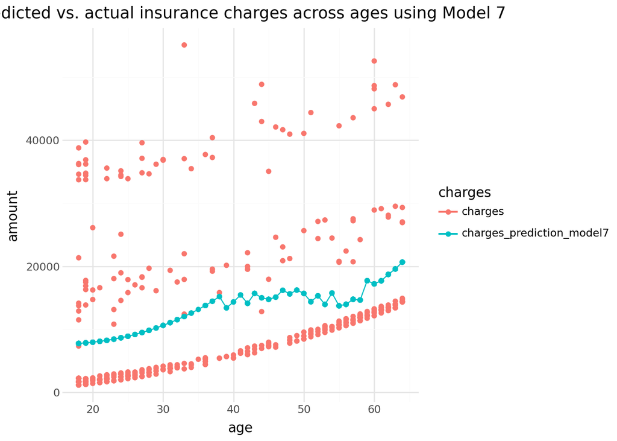

```python
### plot
# add prediction columns
insurance["charges_prediction_model7"] = model_7.predict(insurance[new_cols])
# wide to long
long_plot = insurance.melt(insurance[["age"]], value_vars = ["charges", "charges_prediction_model7"], var_name = "charges", value_name = "amount")

(ggplot(long_plot,
        aes(x = "age",
            y = "amount",
            color = "charges"))
+ geom_point()
+ geom_line(data=long_plot[long_plot["charges"] == "charges_prediction_model7"])
+ labs(title = "Predicted vs. actual insurance charges across ages using Model 7")
+ theme_minimal()
)
```

# 4. New Data

This hidden code imports the new dataset.

```python
# new data
insurance_new = pd.read_csv("https://www.dropbox.com/s/sky86agc4s8c6qe/insurance_costs_2.csv?dl=1")
```

This hidden code defines a custom function for performing cross validation.

```python
def cross_validation (df1, df2, y_var, models):
  """
  Fits a model given data in df1, makes predictions using new data from df2, and reports MSE for each model's predictions

  Parameters
  ----------
  df1: dataframe
    dataframe of training data
  df2: dataframe
    dataframe of test data
  y_var: string
    name of column in both dataframes that includes the y variable used in the model
  models: dict
    dictionary of models that lists each model's x variable(s)

  Return
  ------
  dataframe
    MSE and R-squared values for each provided model
  """
  # initialize empty list
  rows = []

  for name, Xcols in models.items():
    # go thru list of models pulling data from X variables
    X_var = df1[Xcols]
    # fit model based on columns in model list above - using TRAINING data
    model = LinearRegression().fit(X_var, df1[[y_var]])
    # make predictions - using TEST data
    y_var_ = model.predict(df2[Xcols])
    # save it to TEST dataframe
    df2[f"{name}_predict"] = y_var_
    # calculate MSE
    mse = mean_squared_error(df2[[y_var]], y_var_)
    # calculate r-squared
    r2 = r2_score(df2[[y_var]], y_var_)
    # save data to new df
    rows.append({"Model": name, "MSE": mse, "R2": r2})

  df_error = pd.DataFrame(rows)
  return df_error
```

```python
### adjust data for provided models
# make dummies and convert the resulting bools to numbers - test data
insurance_new = pd.get_dummies(insurance_new, drop_first = True)
insurance_new = insurance_new * 1
# omitted dummy variables that are now the benchmark: sex_female, smoker_no, region_northeast

# adding columns for interaction terms - training data
insurance["age:smoker"] = insurance["age"] * insurance["smoker_yes"]
insurance["bmi:smoker"] = insurance["bmi"] * insurance["smoker_yes"]

# adding columns for interaction terms - test data
insurance_new["age:smoker"] = insurance_new["age"] * insurance_new["smoker_yes"]
insurance_new["bmi:smoker"] = insurance_new["bmi"] * insurance_new["smoker_yes"]
```

```python
# list models to compare based on x variables
models = {
    "Model A": ["age"],
    "Model B": ["age", "bmi"],
    "Model C": ["age", "bmi", "smoker_yes"],
    "Model D": ["age", "bmi", "age:smoker", "bmi:smoker"],
    "Model E": ["age", "bmi", "smoker_yes", "age:smoker", "bmi:smoker"]
}

cross_validation(insurance, insurance_new, "charges", models)
```

|  | Model | MSE | R2 |
| --- | --- | --- | --- |
| 0 | Model A | 1.360771e+08 | 0.122365 |
| 1 | Model B | 1.326364e+08 | 0.144556 |
| 2 | Model C | 3.537754e+07 | 0.771831 |
| 3 | Model D | 2.479591e+07 | 0.840078 |
| 4 | Model E | 2.178626e+07 | 0.859489 |

Based on each model’s predictions using the new data, Model E performs the best.

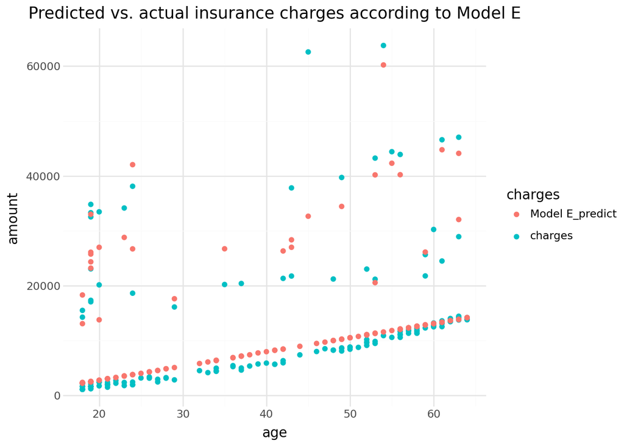

```python
# simplify df
df_plot = insurance_new[["age", "bmi", "charges", "Model E_predict", "smoker_yes", "age:smoker", "bmi:smoker"]]
# wide to long
long_plot = df_plot.melt(id_vars=["age", "bmi", "smoker_yes", "age:smoker", "bmi:smoker"], value_vars = ["charges", "Model E_predict"], var_name = "charges", value_name = "amount")

# plot
(ggplot(long_plot,
        aes(x = "age",
            y = "amount",
            color = "charges"))
+ geom_point()
+ labs(title = "Predicted vs. actual insurance charges according to Model E")
+ theme_minimal()
)
```

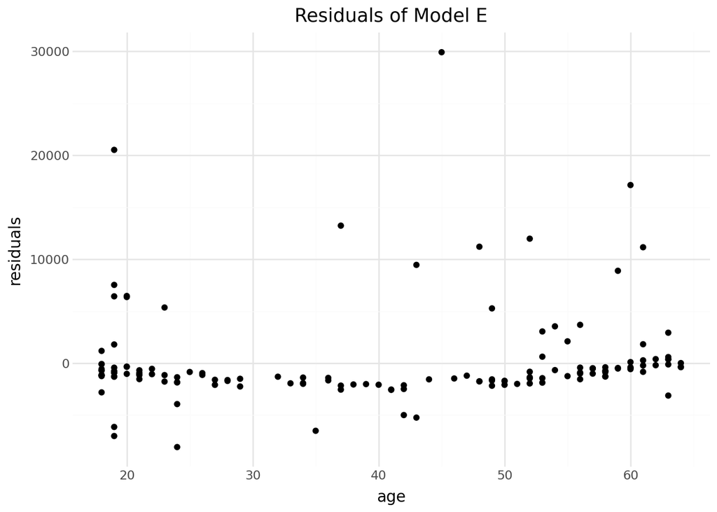

```python
# calculate and save residuals
df_plot["residuals"] = df_plot["charges"] - df_plot["Model E_predict"]

# plot
(ggplot(df_plot,
        aes(x = "age",
            y = "residuals"))
+ geom_point()
+ labs(title = "Residuals of Model E")
+ theme_minimal()
)
```

# 5. Full Exploration

```python
### adjust data for possible models
# adding columns for interaction terms - training data
insurance["age:sex"] = insurance["age"] * insurance["sex_male"]
# adding columns for interaction terms - test data
insurance_new["age:sex"] = insurance_new["age"] * insurance_new["sex_male"]

# adding columns for log of charges - training data
insurance["log_charges"] = np.log(insurance["charges"])
# adding columns for log of charges - test data
insurance_new["log_charges"] = np.log(insurance_new["charges"])

# adding columns for log of ages - training data
insurance["log_age"] = np.log(insurance["age"])
# adding columns for log of ages - test data
insurance_new["log_age"] = np.log(insurance_new["age"])
```

*Note: Models E, F, and G use `charges` as the y-variable.*

```python
# list models to compare based on x variables
models = {
    "Model E": ["age", "bmi", "smoker_yes", "age:smoker", "bmi:smoker"],
    "Model F": ["age", "bmi", "smoker_yes", "age:smoker", "bmi:smoker", "age:sex"],
    "Model G": ["age", "bmi", "smoker_yes", "sex_male", "age:smoker", "bmi:smoker", "age:sex"]
}

cross_validation(insurance, insurance_new, "charges", models)
# note: y-var is charges
```

|  | Model | MSE | R2 |
| --- | --- | --- | --- |
| 0 | Model E | 2.178626e+07 | 0.859489 |
| 1 | Model F | 2.190295e+07 | 0.858736 |
| 2 | Model G | 2.187527e+07 | 0.858915 |

*Note: Models H-M use `log(charges)` as the y-variable.*

```python
# list models to compare based on x variables
models = {
    "Model H": ["age", "bmi", "smoker_yes", "age:smoker", "bmi:smoker"],
    "Model I": ["age", "bmi", "smoker_yes", "age:smoker", "bmi:smoker", "age:sex"],
    "Model J": ["age", "bmi", "smoker_yes", "sex_male", "age:smoker", "bmi:smoker", "age:sex"],
    "Model K": ["log_age", "bmi", "smoker_yes", "age:smoker", "bmi:smoker"],
    "Model L": ["log_age", "bmi", "smoker_yes", "age:smoker", "bmi:smoker", "age:sex"],
    "Model M": ["log_age", "bmi", "smoker_yes", "sex_male", "age:smoker", "bmi:smoker", "age:sex"]
}

cross_validation(insurance, insurance_new, "log_charges", models)
# note: y-var is log(charges)
```

|  | Model | MSE | R2 |
| --- | --- | --- | --- |
| 0 | Model H | 0.115964 | 0.893071 |
| 1 | Model I | 0.116507 | 0.892570 |
| 2 | Model J | 0.112117 | 0.896619 |
| 3 | Model K | 0.111327 | 0.897347 |
| 4 | Model L | 0.111889 | 0.896829 |
| 5 | Model M | 0.108396 | 0.900049 |

I started by experimenting using Model E as a base, since it was so far the best performing model.

First, I tried adding an interaction term between the age and sex variables, since I know that women live longer than men, on average. I tried this by including just the interaction term between age and sex (Model F), and also the variable of sex and the interaction (Model G). These did not improve upon the MSE and R-squared values of Model E.

Next, I transformed the y-variable, charges, by taking its log. This is often helpful with skewed data, and this dataset does have those two distinct bands of higher datapoints. I then fit Models H, I, and J by recreating the list of included x-variables I used in Models E, F, and G, but this time using log(charges) instead of just charges as the y-variable. I found that Model J, which included both the sex variable and the age:sex interaction term, performed the best.

Finally, I wondered if the variable age might lead to a flattening threshold of charges at higher values, so I also tried taking the log of age. I fit Models K, L, and M by recreating the list of included x-variables I used in Models H, I, and J, but this time using log(age) instead of just age.

**Model M performed the best, with an MSE of 0.10839 and an R-squared value of 0.900049. Model M predicts log(charges) based on log(age), bmi, smoker status, sex, interaction of age and smoker, interaction of bmi and smoker, and interaction of age and sex.**

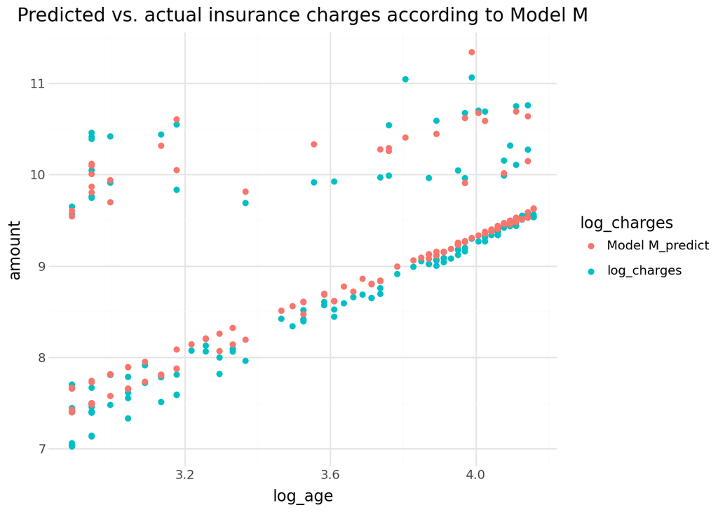

```python
# simplify df
df_plot = insurance_new[["log_age", "bmi", "smoker_yes", "sex_male", "age:smoker", "bmi:smoker", "age:sex", "log_charges", "Model M_predict"]]
# wide to long
long_plot = df_plot.melt(id_vars=["log_age", "bmi", "smoker_yes", "sex_male", "age:smoker", "bmi:smoker", "age:sex"], value_vars = ["log_charges", "Model M_predict"], var_name = "log_charges", value_name = "amount")

# plot
(ggplot(long_plot,
        aes(x = "log_age",
            y = "amount",
            color = "log_charges"))
+ geom_point()
+ labs(title = "Predicted vs. actual insurance charges according to Model M")
+ theme_minimal()
)
```

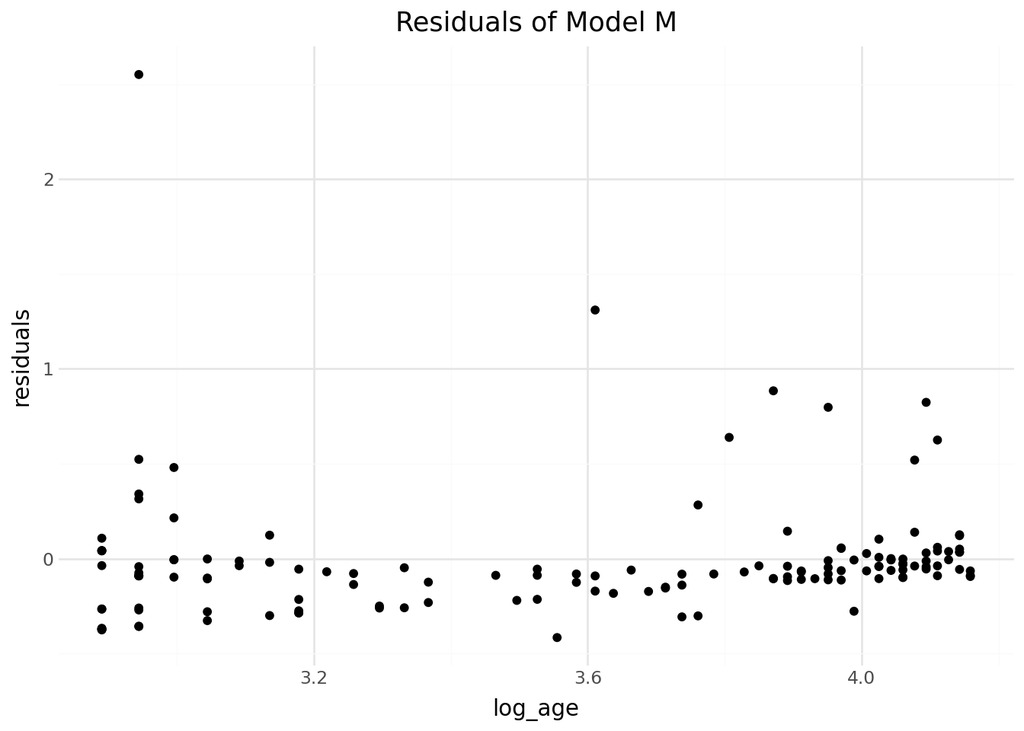

```python
# calculate and save residuals
df_plot["residuals"] = df_plot["log_charges"] - df_plot["Model M_predict"]

# plot
(ggplot(df_plot,
        aes(x = "log_age",
            y = "residuals"))
+ geom_point()
+ labs(title = "Residuals of Model M")
+ theme_minimal()
)
```